# Tarea Número 2

## Pregunta 1

Considere los datos de entrenamiento que se muestran en la siguiente Tabla para un problema de clasificación binaria

[figure not shown]

**1.** Calcule el índice Gini para la tabla completa, observe que el 50% de las filas son de la clase C0 y el 50% son de la clase C1.

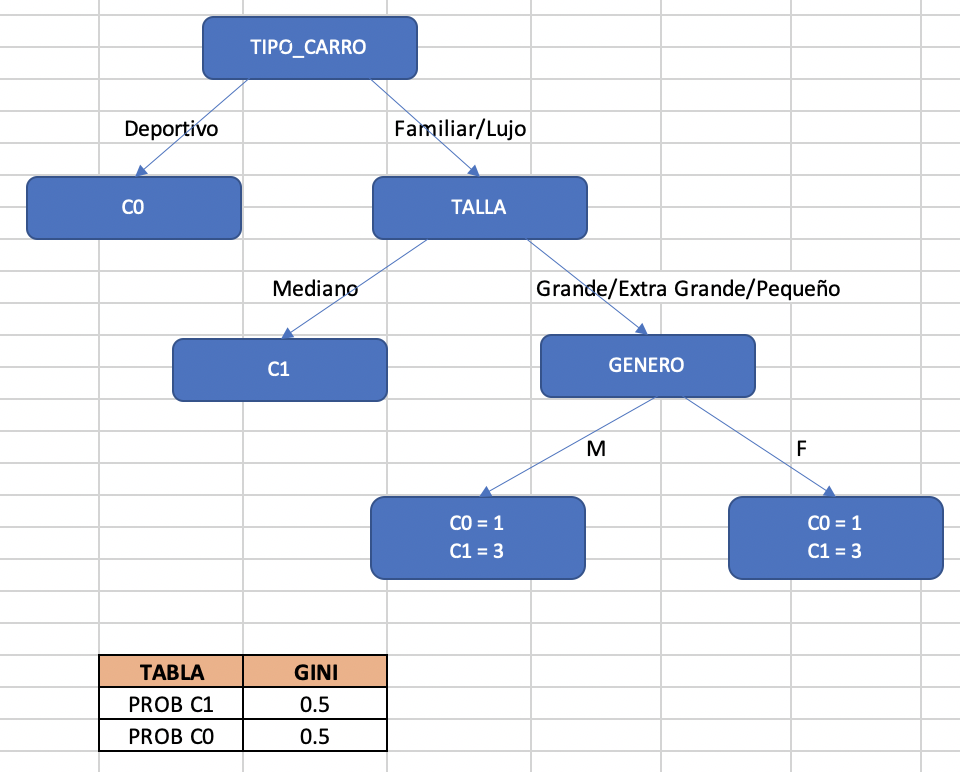

**2.** Calcule el índice de Gini Split para la variable Género.

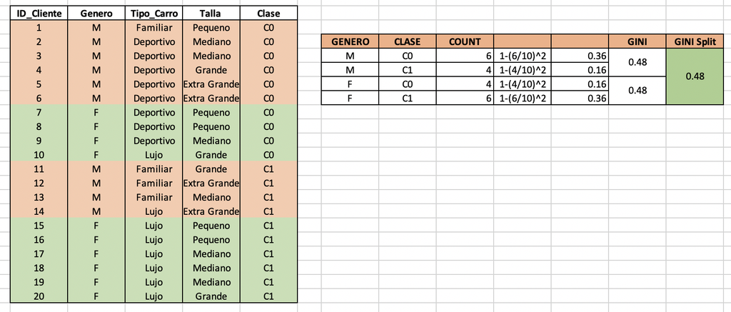

**3.** Calcule el índice de Gini Split para la variable Tipo-Carro.

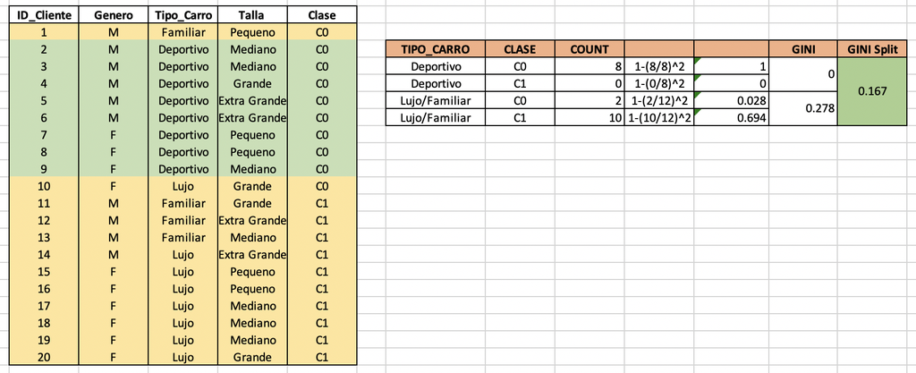

**4.** Calcule el índice de Gini Split para la variable Talla.

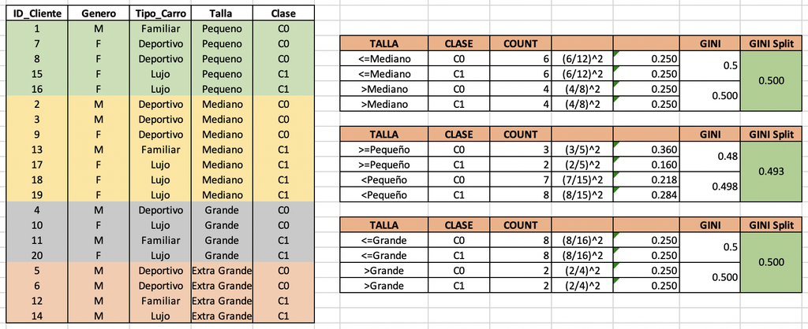

**5.** ¿Cuál variable es mejor Género, Tipo-Carro o Talla?

> **Respuesta:**
> - Definitivamente se descarta la variable Talla ya que es muy impura
> - La variable Género es impura también aunque no tanto como cualquier variante para la variable Talla
> - La variable Tipo Carro tiende de mejor manera a ser pura, por lo que se puede decir que esta es la mejor variable para clasificar

## Pregunta 2

En este ejercicio usaremos los datos (voces.csv). Se trata de un problema de reconocimiento de género mediante el análisis de la voz y el habla. Esta base de datos fue creada para identificar una voz como masculina o femenina, basándose en las propiedades acísticas de la voz y el habla. El conjunto de datos consta de 3.168 muestras de voz grabadas, recogidas de hablantes masculinos y femeninos.

El conjunto de datos tiene las siguientes propiedades acísticas (variables) de cada voz:

- **meanfreq:** frecuencia media (en kHz).
- **sd:** desviación estándar de frecuencia.
- **median:** frecuencia mediana (en kHz).
- **Q25:** primer cuantil (en kHz).
- **Q75:** tercer cuantil (en kHz).
- **IQR:** rango intercuantile (en kHz).
- **skew:** sesgo (ver nota en la descripción de specprop).
- **kurt:** kurtosis (ver nota en la descripción de specprop).
- **sp.ent:** entropía espectral.
- **sfm:** planitud espectral.
- **mode:** modo frecuencia.
- **centroide:** centroide de frecuencia (ver specprop).
- **peakf:** frecuencia de pico (frecuencia con mayor energía).
- **meanfun:** promedio de la frecuencia fundamental medida a través de la señal acústica.
- **minfun:** frecuencia mínima fundamental medida a través de la señal acústica.
- **maxfun:** máxima frecuencia fundamental medida a través de la señal acústica.
- **meandom:** promedio de la frecuencia dominante medida a través de la señal acústica.
- **mindom:** mínimo de la frecuencia dominante medida a través de la señal acústica.
- **maxdom:** máximo de la frecuencia dominante medida a través de la señal acústica.
- **dfrange:** rango de frecuencia dominante medido a través de la señal acústica.
- **modindx:** Índice de modulación. Calculado como la diferencia absoluta acumulada entre las mediciones adyacentes de las frecuencias fundamentales dividida por la gama de frecuencias.
- **genero:** Masculino o Femenino (variable a predecir).

Realice lo siguiente:

**1.** Cargue la tabla de datos voces.csv en Python.

```python
from DataFrameUtils import DataFrameUtils

data2 = DataFrameUtils.read_cvs("./data/voces.csv", delimiter = ",", index_col = None)
print(data2.head())
```

```
   meanfreq        sd    median       Q25       Q75       IQR       skew  \
0  0.059781  0.064241  0.032027  0.015071  0.090193  0.075122  12.863462
1  0.066009  0.067310  0.040229  0.019414  0.092666  0.073252  22.423285
2  0.077316  0.083829  0.036718  0.008701  0.131908  0.123207  30.757155
3  0.151228  0.072111  0.158011  0.096582  0.207955  0.111374   1.232831
4  0.135120  0.079146  0.124656  0.078720  0.206045  0.127325   1.101174

          kurt    sp.ent       sfm  ...  centroid   meanfun    minfun  \
0   274.402906  0.893369  0.491918  ...  0.059781  0.084279  0.015702
1   634.613855  0.892193  0.513724  ...  0.066009  0.107937  0.015826
2  1024.927705  0.846389  0.478905  ...  0.077316  0.098706  0.015656
3     4.177296  0.963322  0.727232  ...  0.151228  0.088965  0.017798
4     4.333713  0.971955  0.783568  ...  0.135120  0.106398  0.016931

     maxfun   meandom    mindom    maxdom   dfrange   modindx     genero
0  0.275862  0.007812  0.007812  0.007812  0.000000  0.000000  Masculino
1  0.250000  0.009014  0.007812  0.054688  0.046875  0.052632  Masculino
2  0.271186  0.007990  0.007812  0.015625  0.007812  0.046512  Masculino
3  0.250000  0.201497  0.007812  0.562500  0.554688  0.247119  Masculino
4  0.266667  0.712812  0.007812  5.484375  5.476562  0.208274  Masculino

[5 rows x 21 columns]
```

**2.** Use Arboles de Decisión en Python (con los parámetros por defecto) para generar un modelo predictivo para la tabla voces.csv usando el 80% de los datos para la tabla aprendizaje y un 20% para la tabla testing, luego calcule para los datos de testing la matriz de confusión, la precisión global y la precisión para cada una de las dos categorías. ¿Son buenos los resultados? Explique.

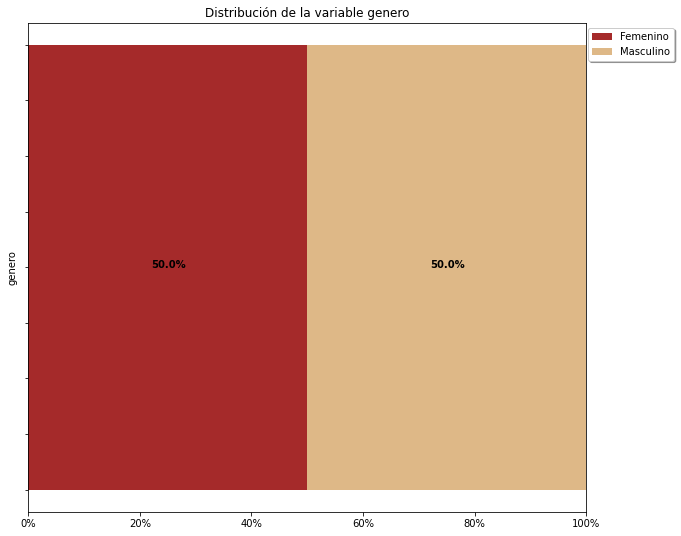

```python
from QualityModel import QualityModel
model2 = QualityModel(data2)
model2.distribution_predict_variable("genero")
```

```python
from PredictiveModel import PredictiveModel

predictiveModel2 = PredictiveModel(data2)
predictiveModel2.build_model("genero", train_size = 0.8)
predictiveModel2.train_model()

confusion_matrix2 = predictiveModel2.obtain_confusion_matrix()
print(f"Matriz de confusión:\n{confusion_matrix2}")
```

```
Variables Predictoras:
   meanfreq        sd    median       Q25       Q75       IQR       skew  \
0  0.059781  0.064241  0.032027  0.015071  0.090193  0.075122  12.863462
1  0.066009  0.067310  0.040229  0.019414  0.092666  0.073252  22.423285
2  0.077316  0.083829  0.036718  0.008701  0.131908  0.123207  30.757155
3  0.151228  0.072111  0.158011  0.096582  0.207955  0.111374   1.232831
4  0.135120  0.079146  0.124656  0.078720  0.206045  0.127325   1.101174

          kurt    sp.ent       sfm      mode  centroid   meanfun    minfun  \
0   274.402906  0.893369  0.491918  0.000000  0.059781  0.084279  0.015702
1   634.613855  0.892193  0.513724  0.000000  0.066009  0.107937  0.015826
2  1024.927705  0.846389  0.478905  0.000000  0.077316  0.098706  0.015656
3     4.177296  0.963322  0.727232  0.083878  0.151228  0.088965  0.017798
4     4.333713  0.971955  0.783568  0.104261  0.135120  0.106398  0.016931

     maxfun   meandom    mindom    maxdom   dfrange   modindx
0  0.275862  0.007812  0.007812  0.007812  0.000000  0.000000
1  0.250000  0.009014  0.007812  0.054688  0.046875  0.052632
2  0.271186  0.007990  0.007812  0.015625  0.007812  0.046512
3  0.250000  0.201497  0.007812  0.562500  0.554688  0.247119
4  0.266667  0.712812  0.007812  5.484375  5.476562  0.208274


Variable a Predecir:
      genero
0  Masculino
1  Masculino
2  Masculino
3  Masculino
4  Masculino


Las predicciones en Testing son:
['Femenino' 'Masculino' 'Femenino' 'Femenino' 'Masculino' 'Masculino'
 'Femenino' 'Femenino' 'Masculino' 'Femenino' 'Masculino' 'Femenino'
 'Femenino' 'Masculino' 'Masculino' 'Femenino' 'Femenino' 'Masculino'
 'Masculino' 'Femenino' 'Femenino' 'Masculino' 'Masculino' 'Femenino'
 'Femenino' 'Masculino' 'Femenino' 'Femenino' 'Femenino' 'Masculino'
 'Femenino' 'Femenino' 'Masculino' 'Masculino' 'Masculino' 'Femenino'
 'Masculino' 'Femenino' 'Masculino' 'Masculino' 'Masculino' 'Femenino'
```

[output cut: 90 more lines]

```
 'Femenino' 'Femenino' 'Femenino' 'Masculino' 'Femenino' 'Masculino'
 'Masculino' 'Masculino' 'Femenino' 'Masculino' 'Masculino' 'Masculino'
 'Femenino' 'Masculino' 'Femenino' 'Femenino' 'Masculino' 'Masculino'
 'Masculino' 'Masculino' 'Masculino' 'Masculino' 'Femenino' 'Masculino'
 'Masculino' 'Masculino' 'Masculino' 'Masculino' 'Femenino' 'Femenino'
 'Femenino' 'Femenino' 'Femenino' 'Masculino' 'Masculino' 'Masculino'
 'Femenino' 'Masculino' 'Masculino' 'Femenino' 'Masculino' 'Femenino'
 'Masculino' 'Masculino' 'Femenino' 'Femenino' 'Femenino' 'Masculino'
 'Femenino' 'Masculino' 'Femenino' 'Femenino']


Matriz de confusión:
           Femenino  Masculino
Femenino        288         13
Masculino        12        321
```

```python
from IndexesCalculator import IndexesCalculator

calculator2 = IndexesCalculator(confusion_matrix2)
print(f"Precisión Global: \n{calculator2.accurancy}\n")
print(f"Precision por Categoría: \n{calculator2.category_precisions}\n")
```

```
Precisión Global:
0.9605678233438486

Precision por Categoría:
   Femenino  Masculino
0  0.956811   0.963964
```

**3.** Usando la función programada en el ejercicio 1 de la tarea anterior, los datos voces.csv y los modelos generados arriba construya un DataFrame de manera que en cada una de las filas aparezca un modelo predictivo y en las columnas aparezcan los índices *Precisión Global, Error Global Precisión Positiva (PP), Precisión Negativa (PN), Falsos Positivos (FP), los Falsos Negativos (FN), la Asertividad Positiva (AP) y la Asertividad Negativa (AN).* ¿Cuál de los modelos es mejor para estos datos?

> **Asumiendo el mismo ejercicio de la tarea 1:** Repita el item d), pero esta vez, seleccione las 6 variables que, segu ́n su criterio, tienen mejor poder predictivo. ¿Mejoran los resultados?

```python
data2_1 = DataFrameUtils.filter_columns(data2, ["sd", "Q25", "IQR", "sfm", "sp.ent", "meanfun", "genero"])

predictiveModel2 = PredictiveModel(data2_1)
predictiveModel2.build_model("genero", train_size = 0.8)
```

```
Variables Predictoras:
         sd       Q25       IQR       sfm    sp.ent   meanfun
0  0.064241  0.015071  0.075122  0.491918  0.893369  0.084279
1  0.067310  0.019414  0.073252  0.513724  0.892193  0.107937
2  0.083829  0.008701  0.123207  0.478905  0.846389  0.098706
3  0.072111  0.096582  0.111374  0.727232  0.963322  0.088965
4  0.079146  0.078720  0.127325  0.783568  0.971955  0.106398


Variable a Predecir:
      genero
0  Masculino
1  Masculino
2  Masculino
3  Masculino
4  Masculino
```

```python
predictiveModel2.train_model()

confusion_matrix2_1 = predictiveModel2.obtain_confusion_matrix()
print(f"Matriz de confusión:\n{confusion_matrix2_1}")

calculator2_1 = IndexesCalculator(confusion_matrix2_1)
print(f"Precisión Global: \n{calculator2_1.accurancy}\n")
print(f"Precision por Categoría: \n{calculator2_1.category_precisions}\n")
```

```
Las predicciones en Testing son:
['Femenino' 'Masculino' 'Femenino' 'Femenino' 'Masculino' 'Masculino'
 'Femenino' 'Femenino' 'Masculino' 'Femenino' 'Masculino' 'Femenino'
 'Femenino' 'Masculino' 'Masculino' 'Femenino' 'Femenino' 'Masculino'
 'Masculino' 'Femenino' 'Femenino' 'Masculino' 'Masculino' 'Femenino'
 'Femenino' 'Masculino' 'Femenino' 'Femenino' 'Femenino' 'Masculino'
 'Femenino' 'Femenino' 'Masculino' 'Masculino' 'Masculino' 'Femenino'
 'Masculino' 'Femenino' 'Masculino' 'Masculino' 'Masculino' 'Femenino'
 'Femenino' 'Masculino' 'Femenino' 'Masculino' 'Masculino' 'Femenino'
 'Masculino' 'Femenino' 'Masculino' 'Masculino' 'Masculino' 'Femenino'
 'Masculino' 'Femenino' 'Femenino' 'Femenino' 'Femenino' 'Masculino'
 'Masculino' 'Masculino' 'Femenino' 'Masculino' 'Masculino' 'Femenino'
 'Femenino' 'Masculino' 'Femenino' 'Femenino' 'Masculino' 'Masculino'
 'Masculino' 'Masculino' 'Masculino' 'Femenino' 'Masculino' 'Masculino'
 'Masculino' 'Femenino' 'Femenino' 'Masculino' 'Masculino' 'Femenino'
 'Masculino' 'Masculino' 'Femenino' 'Femenino' 'Masculino' 'Masculino'
 'Femenino' 'Masculino' 'Femenino' 'Masculino' 'Femenino' 'Femenino'
 'Masculino' 'Masculino' 'Masculino' 'Femenino' 'Femenino' 'Masculino'
 'Femenino' 'Masculino' 'Masculino' 'Masculino' 'Femenino' 'Masculino'
 'Masculino' 'Femenino' 'Femenino' 'Masculino' 'Masculino' 'Masculino'
 'Femenino' 'Femenino' 'Masculino' 'Masculino' 'Femenino' 'Masculino'
 'Femenino' 'Masculino' 'Femenino' 'Femenino' 'Femenino' 'Masculino'
 'Femenino' 'Masculino' 'Masculino' 'Femenino' 'Masculino' 'Femenino'
 'Femenino' 'Femenino' 'Femenino' 'Femenino' 'Femenino' 'Femenino'
 'Femenino' 'Masculino' 'Femenino' 'Femenino' 'Masculino' 'Masculino'
 'Femenino' 'Masculino' 'Masculino' 'Femenino' 'Femenino' 'Masculino'
 'Femenino' 'Masculino' 'Femenino' 'Femenino' 'Masculino' 'Femenino'
 'Masculino' 'Femenino' 'Femenino' 'Femenino' 'Masculino' 'Femenino'
 'Femenino' 'Masculino' 'Masculino' 'Femenino' 'Masculino' 'Femenino'
 'Masculino' 'Femenino' 'Femenino' 'Masculino' 'Femenino' 'Masculino'
 'Femenino' 'Masculino' 'Femenino' 'Femenino' 'Masculino' 'Femenino'
 'Femenino' 'Femenino' 'Femenino' 'Masculino' 'Femenino' 'Femenino'
 'Masculino' 'Femenino' 'Femenino' 'Masculino' 'Masculino' 'Femenino'
 'Femenino' 'Masculino' 'Masculino' 'Masculino' 'Masculino' 'Masculino'
 'Femenino' 'Masculino' 'Masculino' 'Masculino' 'Femenino' 'Femenino'
 'Femenino' 'Femenino' 'Masculino' 'Masculino' 'Masculino' 'Femenino'
 'Femenino' 'Femenino' 'Masculino' 'Masculino' 'Masculino' 'Masculino'
 'Femenino' 'Masculino' 'Masculino' 'Masculino' 'Femenino' 'Femenino'
 'Femenino' 'Masculino' 'Masculino' 'Femenino' 'Masculino' 'Femenino'
 'Masculino' 'Masculino' 'Masculino' 'Masculino' 'Femenino' 'Masculino'
```

[output cut: 64 more lines]

```
 'Femenino' 'Masculino' 'Masculino' 'Femenino' 'Masculino' 'Femenino'
 'Masculino' 'Masculino' 'Masculino' 'Femenino' 'Femenino' 'Masculino'
 'Femenino' 'Masculino' 'Femenino' 'Femenino']


Matriz de confusión:
           Femenino  Masculino
Femenino        292          9
Masculino         8        325
Precisión Global:
0.973186119873817

Precision por Categoría:
   Femenino  Masculino
0    0.9701   0.975976
```

> Teniendo los datos para los dos modelos podemos construir una matriz con los indices de cada una:

```python
rows1 = calculator2.get_indexes_dictionary()
rows2 = calculator2_1.get_indexes_dictionary()

data_dict = DataFrameUtils.create_dataframe_from_dict([rows1, rows2])
print(data_dict)
```

```
   Precisión Global  Error Global  Precisión Femenino  Precisión Masculino  \
0          0.960568      0.039432            0.956811             0.963964
1          0.973186      0.026814            0.970100             0.975976

   Falso Positivo Femenino  Falso Positivo Masculino  Asertividad Femenino  \
0                 0.043189                  0.036036              0.043189
1                 0.029900                  0.024024              0.029900

   Asertividad Masculino
0               0.036036
1               0.024024
```

> **¿Cuál de los modelos es mejor para estos datos?** La matriz que vemos en el cuadro anterior nos muestra que pese a que el primer modelo es optimo para realizar las predicciones de género, la segunda version del modelo es mucho mejor ya que solamente utiliza las 6 variables con mejor poder predictivo, se debería entonces usar el segundo modelo pues sus resultados son óptimos

**4.** Grafique el árbol generado e interprete al menos dos reglas que se puedan extraer del mismo. Si es necesario pode el árbol para que las reglas sean legibles.

```
Las predicciones en Testing son:
['Femenino' 'Masculino' 'Femenino' 'Femenino' 'Masculino' 'Masculino'
 'Femenino' 'Femenino' 'Masculino' 'Femenino' 'Masculino' 'Femenino'
 'Femenino' 'Masculino' 'Masculino' 'Femenino' 'Femenino' 'Masculino'
 'Femenino' 'Femenino' 'Femenino' 'Masculino' 'Masculino' 'Femenino'
 'Femenino' 'Masculino' 'Femenino' 'Femenino' 'Femenino' 'Masculino'
 'Femenino' 'Femenino' 'Masculino' 'Masculino' 'Masculino' 'Femenino'
 'Masculino' 'Femenino' 'Masculino' 'Masculino' 'Masculino' 'Femenino'
 'Femenino' 'Masculino' 'Femenino' 'Masculino' 'Masculino' 'Femenino'
 'Masculino' 'Femenino' 'Masculino' 'Masculino' 'Masculino' 'Femenino'
 'Masculino' 'Femenino' 'Femenino' 'Femenino' 'Femenino' 'Femenino'
 'Femenino' 'Masculino' 'Femenino' 'Masculino' 'Masculino' 'Femenino'
 'Femenino' 'Masculino' 'Femenino' 'Femenino' 'Masculino' 'Masculino'
 'Masculino' 'Masculino' 'Masculino' 'Femenino' 'Masculino' 'Masculino'
 'Masculino' 'Femenino' 'Femenino' 'Masculino' 'Masculino' 'Femenino'
 'Masculino' 'Masculino' 'Femenino' 'Femenino' 'Masculino' 'Masculino'
 'Femenino' 'Masculino' 'Femenino' 'Masculino' 'Femenino' 'Femenino'
 'Masculino' 'Masculino' 'Masculino' 'Femenino' 'Femenino' 'Masculino'
 'Femenino' 'Masculino' 'Masculino' 'Masculino' 'Femenino' 'Masculino'
 'Masculino' 'Femenino' 'Femenino' 'Masculino' 'Masculino' 'Masculino'
 'Femenino' 'Femenino' 'Masculino' 'Masculino' 'Femenino' 'Masculino'
 'Femenino' 'Masculino' 'Femenino' 'Femenino' 'Femenino' 'Masculino'
 'Femenino' 'Masculino' 'Masculino' 'Femenino' 'Masculino' 'Femenino'
 'Femenino' 'Femenino' 'Femenino' 'Femenino' 'Femenino' 'Femenino'
 'Femenino' 'Masculino' 'Femenino' 'Femenino' 'Masculino' 'Masculino'
 'Femenino' 'Masculino' 'Femenino' 'Femenino' 'Femenino' 'Masculino'
 'Femenino' 'Masculino' 'Femenino' 'Femenino' 'Masculino' 'Femenino'
 'Masculino' 'Femenino' 'Masculino' 'Femenino' 'Masculino' 'Femenino'
 'Femenino' 'Masculino' 'Masculino' 'Femenino' 'Masculino' 'Femenino'
 'Masculino' 'Femenino' 'Femenino' 'Masculino' 'Femenino' 'Masculino'
 'Femenino' 'Masculino' 'Femenino' 'Femenino' 'Masculino' 'Femenino'
 'Femenino' 'Femenino' 'Femenino' 'Masculino' 'Femenino' 'Femenino'
 'Femenino' 'Femenino' 'Femenino' 'Femenino' 'Masculino' 'Femenino'
 'Femenino' 'Masculino' 'Masculino' 'Masculino' 'Masculino' 'Masculino'
 'Femenino' 'Masculino' 'Masculino' 'Masculino' 'Femenino' 'Femenino'
 'Femenino' 'Femenino' 'Masculino' 'Masculino' 'Masculino' 'Femenino'
 'Femenino' 'Femenino' 'Masculino' 'Masculino' 'Masculino' 'Masculino'
 'Femenino' 'Masculino' 'Masculino' 'Masculino' 'Femenino' 'Femenino'
 'Masculino' 'Masculino' 'Masculino' 'Femenino' 'Masculino' 'Femenino'
 'Femenino' 'Masculino' 'Masculino' 'Masculino' 'Femenino' 'Masculino'
```

[output cut: 52 more lines]

```
 'Masculino' 'Masculino' 'Masculino' 'Femenino' 'Masculino' 'Femenino'
 'Femenino' 'Masculino' 'Masculino' 'Femenino' 'Masculino' 'Femenino'
 'Masculino' 'Femenino' 'Femenino' 'Femenino' 'Femenino' 'Femenino'
 'Masculino' 'Femenino' 'Femenino' 'Femenino' 'Femenino' 'Masculino'
 'Masculino' 'Femenino' 'Masculino' 'Masculino' 'Masculino' 'Femenino'
 'Masculino' 'Masculino' 'Femenino' 'Masculino' 'Masculino' 'Masculino'
 'Femenino' 'Femenino' 'Femenino' 'Masculino' 'Femenino' 'Masculino'
 'Masculino' 'Femenino' 'Femenino' 'Masculino' 'Masculino' 'Masculino'
 'Femenino' 'Masculino' 'Femenino' 'Femenino' 'Masculino' 'Masculino'
 'Masculino' 'Masculino' 'Femenino' 'Masculino' 'Femenino' 'Masculino'
 'Masculino' 'Masculino' 'Masculino' 'Masculino' 'Femenino' 'Femenino'
 'Femenino' 'Femenino' 'Femenino' 'Masculino' 'Masculino' 'Masculino'
 'Femenino' 'Masculino' 'Masculino' 'Femenino' 'Masculino' 'Femenino'
 'Masculino' 'Masculino' 'Masculino' 'Femenino' 'Masculino' 'Masculino'
 'Femenino' 'Masculino' 'Femenino' 'Femenino']
```

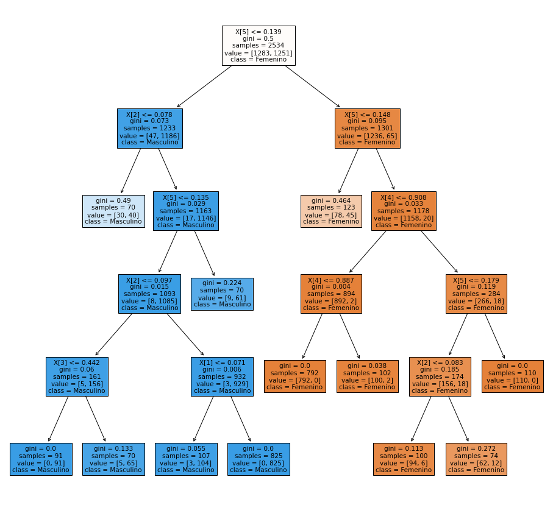

```python
import matplotlib.pyplot as plt
predictiveModel2.train_model(min_samples_leaf = 70)
predictiveModel2.plot_tree_easy()
```

**5.** Repita los ejercicios 1-4, pero esta vez use 2 combinaciones diferentes de los parámetros del método DecisionTreeClassifier. ¿Mejora la predicción?.

```python
data = DataFrameUtils.read_cvs("./data/voces.csv", delimiter = ",", index_col = None)

predictiveModel = PredictiveModel(data)
predictiveModel.build_model("genero", train_size = 0.8)

# Usando criterio gini y min_samples_split 5
predictiveModel.train_model(criterion = "gini", min_samples_leaf = 70, min_samples_split = 5)
confusionMatrix = predictiveModel.obtain_confusion_matrix()
indexes1 = IndexesCalculator(confusionMatrix).get_indexes_dictionary()

# Usando criterio entropia y min_samples_split 2
predictiveModel.train_model(criterion = "entropy", min_samples_leaf = 70, min_samples_split = 2)
confusionMatrix = predictiveModel.obtain_confusion_matrix()
indexes2 = IndexesCalculator(confusionMatrix).get_indexes_dictionary()

# Creando data frame para comparar resultados
data_dict = DataFrameUtils.create_dataframe_from_dict([indexes1, indexes2])
data_dict.index = ["gini", "entropy"]
print(data_dict)
```

```
Variables Predictoras:
   meanfreq        sd    median       Q25       Q75       IQR       skew  \
0  0.059781  0.064241  0.032027  0.015071  0.090193  0.075122  12.863462
1  0.066009  0.067310  0.040229  0.019414  0.092666  0.073252  22.423285
2  0.077316  0.083829  0.036718  0.008701  0.131908  0.123207  30.757155
3  0.151228  0.072111  0.158011  0.096582  0.207955  0.111374   1.232831
4  0.135120  0.079146  0.124656  0.078720  0.206045  0.127325   1.101174

          kurt    sp.ent       sfm      mode  centroid   meanfun    minfun  \
0   274.402906  0.893369  0.491918  0.000000  0.059781  0.084279  0.015702
1   634.613855  0.892193  0.513724  0.000000  0.066009  0.107937  0.015826
2  1024.927705  0.846389  0.478905  0.000000  0.077316  0.098706  0.015656
3     4.177296  0.963322  0.727232  0.083878  0.151228  0.088965  0.017798
4     4.333713  0.971955  0.783568  0.104261  0.135120  0.106398  0.016931

     maxfun   meandom    mindom    maxdom   dfrange   modindx
0  0.275862  0.007812  0.007812  0.007812  0.000000  0.000000
1  0.250000  0.009014  0.007812  0.054688  0.046875  0.052632
2  0.271186  0.007990  0.007812  0.015625  0.007812  0.046512
3  0.250000  0.201497  0.007812  0.562500  0.554688  0.247119
4  0.266667  0.712812  0.007812  5.484375  5.476562  0.208274


Variable a Predecir:
      genero
0  Masculino
1  Masculino
2  Masculino
3  Masculino
4  Masculino


Las predicciones en Testing son:
['Femenino' 'Masculino' 'Femenino' 'Femenino' 'Masculino' 'Masculino'
 'Femenino' 'Femenino' 'Masculino' 'Femenino' 'Masculino' 'Femenino'
 'Femenino' 'Masculino' 'Masculino' 'Femenino' 'Femenino' 'Masculino'
 'Femenino' 'Femenino' 'Femenino' 'Masculino' 'Masculino' 'Femenino'
 'Femenino' 'Masculino' 'Femenino' 'Femenino' 'Femenino' 'Masculino'
 'Femenino' 'Femenino' 'Masculino' 'Masculino' 'Masculino' 'Femenino'
 'Masculino' 'Femenino' 'Masculino' 'Masculino' 'Masculino' 'Femenino'
```

[output cut: 206 more lines]

```
 'Masculino' 'Masculino' 'Masculino' 'Femenino' 'Masculino' 'Masculino'
 'Femenino' 'Masculino' 'Femenino' 'Femenino']


         Precisión Global  Error Global  Precisión Femenino  \
gini             0.944795      0.055205            0.940199
entropy          0.962145      0.037855            0.933555

         Precisión Masculino  Falso Positivo Femenino  \
gini                0.948949                 0.059801
entropy             0.987988                 0.066445

         Falso Positivo Masculino  Asertividad Femenino  Asertividad Masculino
gini                     0.051051              0.059801               0.051051
entropy                  0.012012              0.066445               0.012012
```

> **Respuesta** Se evidencia que la presición usando el criterio de entropía es mas acertado en forma global y para la predicción de masculinos, sin embargo aunque es menor su presición global, el criterio Gini es más acertado para la seleccion de femeninos. Por su presición global se recomendaría usar el criterio de Entropía

**6.** Repita los ejercicios 1-4, pero esta vez use 2 combinaciones diferentes de selección de 6 variables predictoras. ¿Mejora la predicción?.

```python
# ANteriormente ya es utilizó la combinación de las variables "sd", "Q25", "IQR", "sfm", "sp.ent", "meanfun"
# Se utilizarán las siguientes variables para este enunciado:
# "sd", "Q25", "IQR", "sfm", "meanfreq", "skew"

data_cut = DataFrameUtils.read_cvs("./data/voces.csv", delimiter = ",", index_col = None)
data2_2 = DataFrameUtils.filter_columns(data_cut, ["sd", "Q25", "IQR", "sfm", "meanfreq", "skew", "genero"])

predictiveModel2_2 = PredictiveModel(data2_2)
predictiveModel2_2.build_model("genero", train_size = 0.8)
predictiveModel2_2.train_model(criterion = "entropy", min_samples_leaf = 70)
confusionMatrix2_2 = predictiveModel.obtain_confusion_matrix()
indexes2_2 = IndexesCalculator(confusionMatrix2_2).get_indexes_dictionary()

# Creando data frame para comparar resultados
data_dict = DataFrameUtils.create_dataframe_from_dict([rows2, indexes2_2])
data_dict.index = ["OP_1", "OP_2"]
print(data_dict)
```

```
Variables Predictoras:
         sd       Q25       IQR       sfm  meanfreq       skew
0  0.064241  0.015071  0.075122  0.491918  0.059781  12.863462
1  0.067310  0.019414  0.073252  0.513724  0.066009  22.423285
2  0.083829  0.008701  0.123207  0.478905  0.077316  30.757155
3  0.072111  0.096582  0.111374  0.727232  0.151228   1.232831
4  0.079146  0.078720  0.127325  0.783568  0.135120   1.101174


Variable a Predecir:
      genero
0  Masculino
1  Masculino
2  Masculino
3  Masculino
4  Masculino


Las predicciones en Testing son:
['Femenino' 'Masculino' 'Femenino' 'Femenino' 'Masculino' 'Masculino'
 'Masculino' 'Femenino' 'Masculino' 'Femenino' 'Masculino' 'Femenino'
 'Femenino' 'Masculino' 'Femenino' 'Femenino' 'Femenino' 'Masculino'
 'Masculino' 'Femenino' 'Femenino' 'Masculino' 'Masculino' 'Masculino'
 'Femenino' 'Masculino' 'Femenino' 'Femenino' 'Femenino' 'Masculino'
 'Femenino' 'Femenino' 'Masculino' 'Femenino' 'Masculino' 'Femenino'
 'Masculino' 'Femenino' 'Masculino' 'Masculino' 'Masculino' 'Femenino'
 'Femenino' 'Masculino' 'Femenino' 'Masculino' 'Masculino' 'Femenino'
 'Masculino' 'Femenino' 'Masculino' 'Masculino' 'Masculino' 'Masculino'
 'Masculino' 'Masculino' 'Femenino' 'Femenino' 'Femenino' 'Masculino'
 'Masculino' 'Masculino' 'Femenino' 'Masculino' 'Masculino' 'Femenino'
 'Femenino' 'Masculino' 'Femenino' 'Femenino' 'Masculino' 'Masculino'
 'Masculino' 'Masculino' 'Masculino' 'Femenino' 'Masculino' 'Femenino'
 'Masculino' 'Femenino' 'Femenino' 'Masculino' 'Femenino' 'Femenino'
 'Masculino' 'Masculino' 'Masculino' 'Femenino' 'Femenino' 'Masculino'
 'Masculino' 'Femenino' 'Femenino' 'Masculino' 'Masculino' 'Femenino'
 'Masculino' 'Masculino' 'Masculino' 'Femenino' 'Femenino' 'Masculino'
 'Masculino' 'Masculino' 'Masculino' 'Masculino' 'Femenino' 'Masculino'
 'Masculino' 'Femenino' 'Femenino' 'Masculino' 'Femenino' 'Masculino'
 'Femenino' 'Femenino' 'Masculino' 'Masculino' 'Femenino' 'Masculino'
 'Femenino' 'Masculino' 'Femenino' 'Femenino' 'Femenino' 'Masculino'
```

[output cut: 83 more lines]

```
 'Masculino' 'Masculino' 'Masculino' 'Masculino' 'Femenino' 'Masculino'
 'Masculino' 'Masculino' 'Femenino' 'Femenino']


      Precisión Global  Error Global  Precisión Femenino  Precisión Masculino  \
OP_1          0.973186      0.026814            0.970100             0.975976
OP_2          0.962145      0.037855            0.933555             0.987988

      Falso Positivo Femenino  Falso Positivo Masculino  Asertividad Femenino  \
OP_1                 0.029900                  0.024024              0.029900
OP_2                 0.066445                  0.012012              0.066445

      Asertividad Masculino
OP_1               0.024024
OP_2               0.012012
```

## Pregunta 3

Esta pregunta utiliza los datos **(tumores.csv)**. Se trata de un conjunto de datos de características del tumor cerebral que incluye cinco variables de primer orden y ocho de textura y cuatro parámetros de evaluación de la calidad con el nivel objetivo. La variables son: Media, Varianza, Desviación estándar, Asimetría, Kurtosis, Contraste, Energía, ASM (segundo momento angular), Entropía, Homogeneidad, Disimilitud, Correlación, Grosor, PSNR (Pico de la relación señal-ruido), SSIM (Indice de Similitud Estructurada), MSE (Mean Square Error), DC (Coeficiente de Dados) y la variable a predecir tipo (1 = Tumor, 0 = No-Tumor).

Realice lo siguiente:

**1.** Use el método de Arboles de Decisión en Python para generar un modelo predictivo para la tabla tumores.csv usando el 70% de los datos para la tabla aprendizaje y un 20% para la tabla testing.

```python
data_tumores = DataFrameUtils.read_cvs("./data/tumores.csv", delimiter = ",", index_col = 0)

predictiveModel3 = PredictiveModel(data_tumores)
predictiveModel3.build_model("tipo", train_size = 0.7)
```

```
Variables Predictoras:
            media     varianza  desviacion.estandar  entropia  asimetria  \
imagen
Image1  23.448517  2538.985627            50.388348  0.651174   1.984202
Image2   4.398331   834.853030            28.893823  0.953532   6.495203
Image3   3.244263   642.059166            25.338886  0.966065   7.772860
Image4   8.511353  1126.214187            33.559115  0.868765   3.763142
Image5  21.000793  2235.316978            47.279139  0.684724   1.936029

         kurtosis   contraste   energia       asm  homogeneidad  disiminitud  \
imagen
Image1   5.421042  181.467713  0.781557  0.610831      0.847033     2.765411
Image2  43.349355   76.745886  0.972770  0.946281      0.980762     0.548605
Image3  61.756034   81.752406  0.980161  0.960715      0.985066     0.540411
Image4  15.107579  362.291213  0.921786  0.849690      0.949295     2.765725
Image5   4.722343  312.439226  0.804184  0.646711      0.880301     3.006660

        correlacion        psnr      ssim       mse        dc
imagen
Image1     0.968576   97.974630  0.777011  0.171163  0.303989
Image2     0.959751  110.346597  0.977953  0.009913  0.839019
Image3     0.944259  112.266298  0.985362  0.006372  0.849775
Image4     0.859027  101.955792  0.881015  0.068437  0.000000
Image5     0.938572   97.639870  0.766308  0.184878  0.000000


Variable a Predecir:
        tipo
imagen
Image1     1
Image2     1
Image3     1
Image4     0
Image5     0
```

**2.** Usando la función programada en el ejercicio 1 de la tarea anterior, los datos tumores.csv y los modelos generados arriba construya un DataFrame de manera que en cada una de las filas aparezca un modelo predictivo y en las columnas aparezcan losíndices Precisión Global, Error Global Precisión Positiva (PP), Precisión Negativa (PN), Falsos Positivos (FP), los Falsos Negativos (FN), la Asertividad Positiva (AP) y la Asertividad Negativa (AN). ¿Cuál de los modelos es mejor para estos datos?

```python
predictiveModel3.train_model(criterion = "gini")
confusionMatrix3 = predictiveModel3.obtain_confusion_matrix()
indexes3 = IndexesCalculator(confusionMatrix3).get_indexes_dictionary()

print(indexes3)
```

[output not shown]

**3.** Grafique el árbol generado e interprete al menos dos reglas que se puedan extraer del mismo. Si es necesario pode el árbol para que las reglas sean legibles.

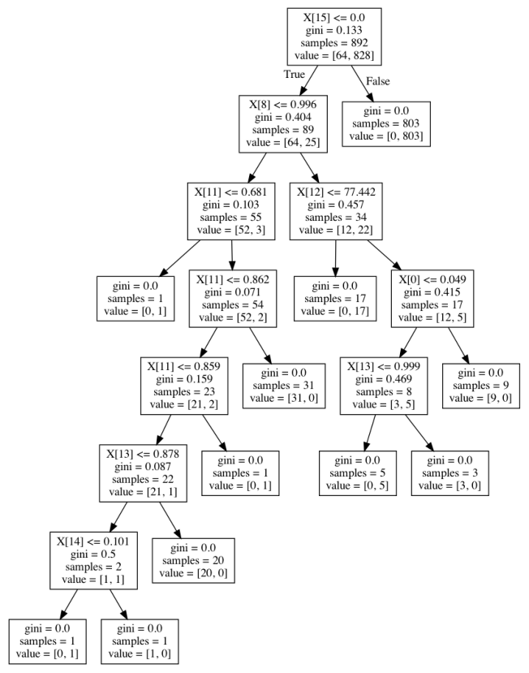

```python
predictiveModel3.plot_tree()
```

## Pregunta 4

En este ejercicio vamos a predecir nímeros escritos a mano (Hand Written Digit Recognition), la tabla de aprendizaje está en el archivo ZipDataTrainCod.csv y la tabla de testing está en el archivo ZipDataTestCod.csv. En la figura siguiente se ilustran los datos:

[figure not shown]

Los datos de este ejemplo vienen de los códigos postales escritos a mano en sobres del correo postal de EE.UU. Las imágenes son de 16 × 16 en escala de grises, cada pixel va de intensidad de −1 a 1 (de blanco a negro). Las imágenes se han normalizado para tener aproximadamente el mismo tamaño y orientación. La tarea consiste en predecir, a partir de la matriz de 16 × 16 de intensidades de cada pixel, la identidad de cada imagen (0,1,...,9) de forma rápida y precisa. Si es lo suficientemente precisa, el algoritmo resultante se utiliza como parte de un procedimiento de selección automática para sobres. Este es un problema de clasificación para el cual la tasa de error debe mantenerse muy baja para evitar la mala dirección de correo. La columna 1 tiene la variable a predecir Nímero codificada como sigue: 0=‘cero’; 1=‘uno’; 2=‘dos’; 3=‘tres’; 4=‘cuatro’; 5=‘cinco’;6=‘seis’; 7=‘siete’; 8=‘ocho’ y 9=‘nueve’, las demás columnas son las variables predictivas, además cada fila de la tabla representa un bloque 16 × 16 por lo que la matriz tiene 256 variables predictoras.

**1.** Usando Arboles de Decisión más cercanos un modelo predictivo para la tabla de aprendizaje.

```python
data_train = DataFrameUtils.read_cvs("./data/ZipDataTrainCod.csv", index_col = None)
print(data_train.head())

data_test = DataFrameUtils.read_cvs("./data/ZipDataTestCod.csv", index_col = None)
print(data_test.head())

predictiveModel = PredictiveModel()
predictiveModel.build_model_with_data("Numero", data_train, data_test)

predictiveModel.train_model()
```

```
   Numero   V2   V3   V4     V5     V6     V7     V8     V9    V10  ...  \
0    seis -1.0 -1.0 -1.0 -1.000 -1.000 -1.000 -1.000 -0.631  0.862  ...
1   cinco -1.0 -1.0 -1.0 -0.813 -0.671 -0.809 -0.887 -0.671 -0.853  ...
2  cuatro -1.0 -1.0 -1.0 -1.000 -1.000 -1.000 -1.000 -1.000 -1.000  ...
3   siete -1.0 -1.0 -1.0 -1.000 -1.000 -0.273  0.684  0.960  0.450  ...
4    tres -1.0 -1.0 -1.0 -1.000 -1.000 -0.928 -0.204  0.751  0.466  ...

    V248   V249   V250   V251   V252   V253   V254   V255   V256  V257
0  0.304  0.823  1.000  0.482 -0.474 -0.991 -1.000 -1.000 -1.000  -1.0
1 -0.671 -0.671 -0.033  0.761  0.762  0.126 -0.095 -0.671 -0.828  -1.0
2 -1.000 -1.000 -1.000 -0.109  1.000 -0.179 -1.000 -1.000 -1.000  -1.0
3 -0.318  1.000  0.536 -0.987 -1.000 -1.000 -1.000 -1.000 -1.000  -1.0
4  0.466  0.639  1.000  1.000  0.791  0.439 -0.199 -0.883 -1.000  -1.0

[5 rows x 257 columns]
  Numero   V2   V3   V4     V5   V6     V7     V8     V9    V10  ...   V248  \
0  nueve -1.0 -1.0 -1.0 -1.000 -1.0 -0.948 -0.561  0.148  0.384  ... -1.000
1   seis -1.0 -1.0 -1.0 -1.000 -1.0 -1.000 -1.000 -1.000 -1.000  ... -1.000
2   tres -1.0 -1.0 -1.0 -0.593  0.7  1.000  1.000  1.000  1.000  ...  1.000
3   seis -1.0 -1.0 -1.0 -1.000 -1.0 -1.000 -1.000 -1.000 -1.000  ... -1.000
4   seis -1.0 -1.0 -1.0 -1.000 -1.0 -1.000 -1.000 -0.858 -0.106  ...  0.901

    V249   V250   V251   V252   V253  V254  V255  V256  V257
0 -0.908  0.430  0.622 -0.973 -1.000  -1.0  -1.0  -1.0  -1.0
1 -1.000 -1.000 -1.000 -1.000 -1.000  -1.0  -1.0  -1.0  -1.0
2  0.717  0.333  0.162 -0.393 -1.000  -1.0  -1.0  -1.0  -1.0
3 -1.000 -1.000 -1.000 -1.000 -1.000  -1.0  -1.0  -1.0  -1.0
4  0.901  0.901  0.290 -0.369 -0.867  -1.0  -1.0  -1.0  -1.0

[5 rows x 257 columns]
Las predicciones en Testing son:
['nueve' 'seis' 'tres' ... 'cuatro' 'cero' 'uno']
```

**2.** Con la tabla de testing calcule la matriz de confusión, la precisión global, el error global y la precisión en cada unos de los dígitos. ¿Son buenos los resultados? Además compare respecto a los resultados obtenidos en la tarea anterior.

```python
confusion_matrix = predictiveModel.obtain_confusion_matrix()
print(f"Matriz de confusión:\n{confusion_matrix}")
```

```
Matriz de confusión:
        cero  cinco  cuatro  dos  nueve  ocho  seis  siete  tres  uno
cero     330      8       5    7      0     4     2      1     2    0
cinco      8    117       6    3      3     4     0      2    17    0
cuatro     5      4     157    6     13     4     4      2     1    4
dos        7      1       6  155      2    12     5      3     6    1
nueve      2      2      11    3    141     7     0      5     3    3
ocho       6      4       7    9      8   114     7      3     7    1
seis       3      3       4    8      0     1   145      0     4    2
siete      0      0       5    1      5     0     2    128     3    3
tres       5     18       1    6      4     4     2      0   125    1
uno        0      0       6    1      1     7     3      1     0  245
```

```python
calculator = IndexesCalculator(confusion_matrix)
print(f"Precisión Global: \n{calculator.accurancy}\n")
print(f"Error Global: \n{calculator.error_rate}\n")
print(f"Precision por Categoría: \n{calculator.category_precisions}\n")
```

```
Precisión Global:
0.8256103637269556

Error Global:
0.17438963627304438

Precision por Categoría:
      cero    cinco  cuatro       dos    nueve      ocho      seis     siete  \
0  0.91922  0.73125   0.785  0.782828  0.79661  0.686747  0.852941  0.870748

       tres      uno
0  0.753012  0.92803
```

#### Datos de la Tarea Anterior:

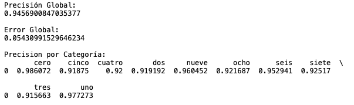

> Si comparamos los dato con la tarea anterior se puede evidenciar que el modelo de árboles de decisión es menos acertada para predecir los numeros en este caso los indices son de la tarea anterior son mejores globalmente y por categoría

**3.** Repita los ejercicios 1, 2 y 3 pero usando solamente los 3s, 5s y los 8s. ¿Mejora la predicción?

```python
data_train = DataFrameUtils.read_cvs("./data/ZipDataTrainCod.csv", index_col = None)
data_train = DataFrameUtils.filter_rows(data_train, "Numero", ["tres", "cinco", "ocho"])
data_test = DataFrameUtils.read_cvs("./data/ZipDataTestCod.csv", index_col = None)
data_test = DataFrameUtils.filter_rows(data_test, "Numero", ["tres", "cinco", "ocho"])

predictiveModel = PredictiveModel()
predictiveModel.build_model_with_data("Numero", data_train, data_test)
predictiveModel.train_model()

confusion_matrix = predictiveModel.obtain_confusion_matrix()

calculator = IndexesCalculator(confusion_matrix)
print(f"Precisión Global: \n{calculator.accurancy}\n")
print(f"Error Global: \n{calculator.error_rate}\n")
print(f"Precision por Categoría: \n{calculator.category_precisions}\n")
```

```
Las predicciones en Testing son:
['tres' 'tres' 'cinco' 'tres' 'tres' 'cinco' 'cinco' 'ocho' 'ocho' 'cinco'
 'cinco' 'ocho' 'tres' 'ocho' 'ocho' 'tres' 'ocho' 'tres' 'tres' 'cinco'
 'tres' 'cinco' 'cinco' 'ocho' 'cinco' 'cinco' 'ocho' 'cinco' 'tres'
 'cinco' 'ocho' 'tres' 'tres' 'ocho' 'cinco' 'ocho' 'tres' 'ocho' 'cinco'
 'ocho' 'ocho' 'ocho' 'tres' 'ocho' 'tres' 'ocho' 'tres' 'cinco' 'cinco'
 'cinco' 'ocho' 'ocho' 'ocho' 'tres' 'ocho' 'tres' 'ocho' 'tres' 'tres'
 'tres' 'tres' 'cinco' 'ocho' 'tres' 'ocho' 'ocho' 'cinco' 'cinco' 'tres'
 'ocho' 'cinco' 'ocho' 'tres' 'tres' 'cinco' 'ocho' 'tres' 'cinco' 'ocho'
 'tres' 'cinco' 'tres' 'tres' 'ocho' 'tres' 'ocho' 'ocho' 'ocho' 'tres'
 'cinco' 'ocho' 'ocho' 'cinco' 'ocho' 'ocho' 'ocho' 'cinco' 'ocho' 'cinco'
 'cinco' 'ocho' 'cinco' 'cinco' 'tres' 'tres' 'ocho' 'ocho' 'ocho' 'ocho'
 'cinco' 'tres' 'tres' 'cinco' 'ocho' 'ocho' 'tres' 'cinco' 'tres' 'ocho'
 'ocho' 'tres' 'cinco' 'tres' 'cinco' 'cinco' 'tres' 'tres' 'cinco' 'ocho'
 'ocho' 'tres' 'tres' 'tres' 'tres' 'cinco' 'ocho' 'cinco' 'cinco' 'cinco'
 'cinco' 'tres' 'cinco' 'ocho' 'ocho' 'tres' 'ocho' 'tres' 'tres' 'ocho'
 'tres' 'ocho' 'cinco' 'cinco' 'ocho' 'ocho' 'tres' 'ocho' 'ocho' 'tres'
 'cinco' 'tres' 'cinco' 'cinco' 'tres' 'tres' 'tres' 'tres' 'cinco' 'tres'
 'tres' 'cinco' 'ocho' 'ocho' 'cinco' 'tres' 'tres' 'ocho' 'tres' 'tres'
 'tres' 'ocho' 'tres' 'cinco' 'ocho' 'ocho' 'tres' 'tres' 'cinco' 'tres'
 'ocho' 'tres' 'ocho' 'ocho' 'cinco' 'ocho' 'ocho' 'ocho' 'ocho' 'cinco'
 'tres' 'ocho' 'cinco' 'ocho' 'tres' 'ocho' 'ocho' 'tres' 'ocho' 'cinco'
 'ocho' 'tres' 'cinco' 'cinco' 'ocho' 'cinco' 'ocho' 'tres' 'ocho' 'ocho'
 'ocho' 'ocho' 'ocho' 'ocho' 'ocho' 'ocho' 'cinco' 'tres' 'tres' 'tres'
 'ocho' 'ocho' 'cinco' 'cinco' 'tres' 'ocho' 'cinco' 'cinco' 'ocho' 'tres'
 'cinco' 'cinco' 'tres' 'cinco' 'cinco' 'cinco' 'ocho' 'ocho' 'tres'
 'cinco' 'cinco' 'ocho' 'cinco' 'tres' 'cinco' 'cinco' 'tres' 'tres'
 'tres' 'tres' 'tres' 'ocho' 'tres' 'tres' 'cinco' 'tres' 'cinco' 'tres'
 'tres' 'cinco' 'cinco' 'ocho' 'ocho' 'cinco' 'cinco' 'tres' 'ocho' 'tres'
 'ocho' 'ocho' 'ocho' 'tres' 'cinco' 'cinco' 'cinco' 'cinco' 'ocho' 'tres'
 'cinco' 'tres' 'cinco' 'ocho' 'cinco' 'cinco' 'tres' 'ocho' 'ocho' 'ocho'
 'tres' 'tres' 'tres' 'ocho' 'ocho' 'ocho' 'tres' 'tres' 'ocho' 'ocho'
 'cinco' 'ocho' 'cinco' 'ocho' 'cinco' 'ocho' 'cinco' 'cinco' 'cinco'
 'tres' 'tres' 'ocho' 'ocho' 'cinco' 'cinco' 'ocho' 'tres' 'cinco' 'ocho'
 'cinco' 'cinco' 'cinco' 'cinco' 'tres' 'ocho' 'cinco' 'ocho' 'cinco'
 'cinco' 'tres' 'tres' 'cinco' 'tres' 'ocho' 'tres' 'tres' 'ocho' 'ocho'
 'cinco' 'ocho' 'tres' 'tres' 'tres' 'tres' 'tres' 'cinco' 'cinco' 'ocho'
 'cinco' 'tres' 'cinco' 'cinco' 'tres' 'tres' 'tres' 'cinco' 'tres' 'tres'
 'ocho' 'ocho' 'cinco' 'ocho' 'tres' 'tres' 'cinco' 'ocho' 'ocho' 'ocho'
 'ocho' 'tres' 'tres' 'tres' 'tres' 'tres' 'ocho' 'ocho' 'cinco' 'cinco'
```

[output cut: 8 more lines]

```
 'cinco' 'cinco' 'cinco' 'cinco' 'tres' 'cinco' 'ocho' 'cinco' 'cinco'
 'ocho' 'ocho' 'tres' 'cinco' 'ocho' 'tres' 'ocho' 'cinco' 'cinco' 'ocho'
 'cinco' 'cinco' 'tres' 'cinco' 'ocho' 'cinco' 'ocho' 'cinco' 'ocho'
 'ocho' 'cinco' 'tres' 'cinco' 'tres']


Precisión Global:
0.823170731707317

Error Global:
0.17682926829268297

Precision por Categoría:
     cinco      ocho      tres
0  0.84375  0.843373  0.783133
```

**4.** Repita los ejercicios 1, 2 y 3 pero reemplazando cada bloque 4 × 4 de píxeles por su promedio. ¿Mejora la predicción? Recuerde que cada bloque 16 × 16 está representado por una fila en las matrices de aprendizaje y testing. **Despliegue la matriz de confusión resultante.**

```python
data_test = DataFrameUtils.read_cvs("./data/ZipDataTestCod.csv", index_col = None)
data_test = DataFrameUtils.replace_all_by_average(data_test, "Numero")
data_train = DataFrameUtils.read_cvs("./data/ZipDataTrainCod.csv", index_col = None)
data_train = DataFrameUtils.replace_all_by_average(data_train, "Numero")

predictiveModel = PredictiveModel()
predictiveModel.build_model_with_data("Numero", data_train, data_test)
predictiveModel.train_model()
```

```
Las predicciones en Testing son:
['nueve' 'seis' 'dos' ... 'cuatro' 'cero' 'uno']
```

```python
confusion_matrix = predictiveModel.obtain_confusion_matrix()
print(f"Matriz de confusión:\n{confusion_matrix}")
```

```
Matriz de confusión:
        cero  cinco  cuatro  dos  nueve  ocho  seis  siete  tres  uno
cero     328      3       2    4      1     7     5      1     4    4
cinco      8    114       2    3      2     8     3      2    17    1
cuatro     3      3     148    8     18     4     4      7     2    3
dos        8      5       2  166      1     5     2      0     7    2
nueve      0      2      15    1    149     6     0      4     0    0
ocho      14      6       6    4     11   105     1      3     4   12
seis      14      3       0    5      0     2   144      0     0    2
siete      0      2       4    0     10     2     0    123     5    1
tres       8     24       0   13      3     8     0      4   106    0
uno        6      0       3    2      2    11     2      3     0  235
```

```python
calculator = IndexesCalculator(confusion_matrix)
print(f"Precisión Global: \n{calculator.accurancy}\n")
print(f"Error Global: \n{calculator.error_rate}\n")
print(f"Precision por Categoría: \n{calculator.category_precisions}\n")
```

```
Precisión Global:
0.8061783756851021

Error Global:
0.1938216243148979

Precision por Categoría:
       cero   cinco  cuatro       dos     nueve     ocho      seis     siete  \
0  0.913649  0.7125    0.74  0.838384  0.841808  0.63253  0.847059  0.836735

       tres       uno
0  0.638554  0.890152
```

> Las predicciones no mejoram, se tiene menos evidencia por lo tanto no se puede realizar un buen entrenamiento del modelo, si se disminuye el modelo por un promedio de sus elementos continuará decreciendo el poder de prediccion del modelo, no vale la pena realizar el siguiente ítem del ejercicio

**5.** Repita los ejercicios 1, 2 y 3 pero reemplazando cada bloque p × p de píxeles por su promedio. ¿Mejora la predicción? (pruebe con algunos valores de p). **Despliegue las matrices de confusión resultantes.**

## Clases Utilizadas

```python
# %load PredictiveModel.py

from sklearn.model_selection import train_test_split
from sklearn import tree
from sklearn.metrics import confusion_matrix
from DataFrameUtils import DataFrameUtils
from pandas import DataFrame
import matplotlib.pyplot as plt
import matplotlib.image as mpimg
import graphviz

class PredictiveModel:

    # Constructor
    def __init__(self, data = None):
        self.__data = data
        self.__X = None
        self.__Y = None
        self.__train_size = None
        self.__n_neighbors = None
        self.__tree_instance = None
        self.__confusion_matrix = None
        self.X_train = None
        self.X_test = None
        self.y_train = None
        self.y_test = None

    def build_model(self, variable_predict, train_size = 0.7):
        print("Variables Predictoras:")
        self.X = self.data.loc[:,self.data.columns != variable_predict]
        print(self.X.head())
        print("\n")
        print("Variable a Predecir:")
        self.Y = self.data.loc[:,self.data.columns == variable_predict]
        print(self.Y.head())
        self.X_train, self.X_test, self.y_train, self.y_test = train_test_split(self.X, self.Y, train_size = train_size, random_state=0)
        print("\n")

    def build_model_with_data(self, variable_predict, train_df: DataFrame, test_df: DataFrame, algorithm = "auto"):
        self.X_train = train_df.loc[:, train_df.columns != variable_predict]
        self.X_test = test_df.loc[:, test_df.columns != variable_predict]
        self.y_train = train_df.loc[:,train_df.columns == variable_predict]
        self.y_test = test_df.loc[:,test_df.columns == variable_predict]

    def train_model(self, criterion = "gini", min_samples_leaf = 1, min_samples_split = 2):
        self.tree_instance = tree.DecisionTreeClassifier(random_state=0, criterion=criterion, min_samples_leaf = min_samples_leaf, min_samples_split=min_samples_split)
        self.tree_instance.fit(self.X_train,self.y_train)
        print("Las predicciones en Testing son:\n{}".format(self.tree_instance.predict(self.X_test)))
        print("\n")

    def obtain_confusion_matrix(self):
        if self.tree_instance == None:
            print("Se debe inicializar el modelo para poder obtener la matriz de confusión")
            return None
        prediccion = self.tree_instance.predict(self.X_test)
        self.confusion_matrix = confusion_matrix(self.y_test, prediccion)
        return DataFrameUtils.create_dataframe(self.confusion_matrix, indexes=self.tree_instance.classes_, columns=self.tree_instance.classes_)

    def plot_tree_easy(self):
        plt.figure(figsize=(16,15))
        tree.plot_tree(self.tree_instance.fit(self.X_train,self.y_train), class_names=self.tree_instance.classes_, filled=True)

    def plot_tree(self):
        plt.figure(figsize=(16,15))
        dot_data = tree.export_graphviz(self.tree_instance.fit(self.X_train,self.y_train), out_file=None)
        graph = graphviz.Source(dot_data)
        graph.format = "png"
        graphic_file = graph.render()
        img = mpimg.imread(graphic_file)
        plt.imshow(img)
        plt.axis('off')

    @property
    def data(self):
        return self.__data

    @data.setter
    def data(self, data):
        self.__data = data

    @property
    def X(self):
        return self.__X

    @X.setter
    def X(self, X):
        self.__X = X

    @property
    def Y(self):
        return self.__Y

    @Y.setter
    def Y(self, Y):
        self.__Y = Y

    @property
    def train_size(self):
        return self.__train_size

    @train_size.setter
    def train_size(self, train_size):
        self.__train_size = train_size

    @property
    def tree_instance(self):
        return self.__tree_instance

    @tree_instance.setter
    def tree_instance(self, tree_instance):
        self.__tree_instance = tree_instance

    @property
    def confusion_matrix(self):
        return self.__confusion_matrix

    @confusion_matrix.setter
    def confusion_matrix(self, confusion_matrix):
        self.__confusion_matrix = confusion_matrix
```

```python
# %load QualityModel.py
from IndexesCalculator import IndexesCalculator
from sklearn.metrics import confusion_matrix
import seaborn as sns
from pandas import DataFrame
import pandas as pd
import matplotlib.pyplot as plt
import numpy as np
from matplotlib import colors as mcolors

class QualityModel:

    # Constructor
    def __init__(self, data):
        self.__calculator = IndexesCalculator(data)
        self.__data = data

    def predictive_power_by_variable(self):
        for column in self.data.columns[:-1]:
            self.numeric_predictive_power(column, "genero")

    def numeric_predictive_power(self, var:str, variable_predict:str):
        sns.FacetGrid(self.data, hue=variable_predict, height=6).map(sns.kdeplot, var, shade=True).add_legend()

    def poder_predictivo_categorica(self, var:str, variable_predict:str):
        df = pd.crosstab(index= self.data[var],columns=self.data[variable_predict])
        df = df.div(df.sum(axis=1),axis=0)
        titulo = "Distribución de la variable %s según la variable %s" % (var,variable_predict)
        g = df.plot(kind='barh',stacked=True,legend = True, figsize = (10,9), \
                    xlim = (0,1),title = titulo, width = 0.8)
        vals = g.get_xticks()
        g.set_xticklabels(['{:.0%}'.format(x) for x in vals])
        g.legend(loc='upper center', bbox_to_anchor=(1.08, 1), shadow=True, ncol=1)
        for bars in g.containers:
            plt.setp(bars, width=.9)
        for i in range(df.shape[0]):
            countv = 0
            for v in df.iloc[i]:
                g.text(np.mean([countv,countv+v]) - 0.03, i , '{:.1%}'.format(v), color='black', fontweight='bold')
                countv = countv + v

    def distribution_predict_variable(self, variable_predict:str):
        colors = list(dict(**mcolors.CSS4_COLORS))
        df = pd.crosstab(index=self.data[variable_predict],columns="valor") / self.data[variable_predict].count()
        fig = plt.figure(figsize=(10,9))
        g = fig.add_subplot(111)
        countv = 0
        titulo = "Distribución de la variable %s" % variable_predict
        for i in range(df.shape[0]):
            g.barh(1,df.iloc[i],left = countv, align='center',color=colors[11+i],label= df.iloc[i].name)
            countv = countv + df.iloc[i]
        vals = g.get_xticks()
        g.set_xlim(0,1)
        g.set_yticklabels("")
        g.set_title(titulo)
        g.set_ylabel(variable_predict)
        g.set_xticklabels(['{:.0%}'.format(x) for x in vals])
        countv = 0
        for v in df.iloc[:,0]:
            g.text(np.mean([countv,countv+v]) - 0.03, 1 , '{:.1%}'.format(v), color='black', fontweight='bold')
            countv = countv + v
        g.legend(loc='upper center', bbox_to_anchor=(1.08, 1), shadow=True, ncol=1)

    @property
    def data(self):
        return self.__data

    @data.setter
    def data(self, data):
        self.__data = data
```

```python
# %load IndexesCalculator.py
import numpy as np
import pandas as pd

class IndexesCalculator:

    def __init__(self, confusion_matrix):
        self.__confusion_matrix = confusion_matrix
        self.__matrix = confusion_matrix.to_numpy()
        self.__accurancy = None
        self.__error_rate = None
        self.__category_precisions = pd.DataFrame()
        self.__false_by_category = None
        self.__assertiveness_by_category = None

    def show_confusion_matrix_indexes(self):
        print(f"Matriz de Confusión: \n{self.confusion_matrix}\n")
        print(f"Precisión Global: {self.accurancy}")
        print(f"Error Global: {self.error_rate}")
        print(f"Precision por Categoría:\n{self.category_precisions}\n")
        print(f"Falsos Positivos por Categoría: \n{self.false_by_category}\n")
        print(f"Asertividad por Categoría: \n{self.assertiveness_by_category}\n")

    def get_indexes_dictionary(self):
        indexes = {
            "Precisión Global": self.accurancy,
            "Error Global": self.error_rate
        }
        for col in self.category_precisions.columns:
            indexes[f"Precisión {col}"] = self.__category_precisions[col].iloc[0]
        for col in self.false_by_category.columns:
            indexes[f"Falso Positivo {col}"] = self.__false_by_category[col].iloc[0]
        for col in self.assertiveness_by_category.columns:
            indexes[f"Asertividad {col}"] = self.__false_by_category[col].iloc[0]
        return indexes

    @property
    def confusion_matrix(self):
        return self.__confusion_matrix

    @confusion_matrix.setter
    def confusion_matrix(self, confusion_matrix):
        self.__confusion_matrix = confusion_matrix

    @property
    def accurancy(self):
        if self.__accurancy == None:
            self.__accurancy = np.sum(self.__matrix.diagonal()) / np.sum(self.__matrix)
        return self.__accurancy

    @accurancy.setter
    def accurancy(self, accurancy):
        self.__accurancy = accurancy

    @property
    def error_rate(self):
        if self.__error_rate == None:
            self.__error_rate = 1 - self.accurancy
        return self.__error_rate

    @error_rate.setter
    def error_rate(self, error_rate):
        self.__error_rate = error_rate

    @property
    def category_precisions(self):
        if self.__category_precisions.empty:
            self.__category_precisions = pd.DataFrame(self.__matrix.diagonal() / np.sum(self.__matrix, axis = 1)).T
            self.__category_precisions.columns = self.confusion_matrix.columns
        return self.__category_precisions

    @category_precisions.setter
    def category_precisions(self, category_precisions):
        self.__category_precisions = category_precisions

    @property
    def false_by_category(self):
        if self.__false_by_category == None:
            self.__false_by_category = pd.DataFrame(np.fliplr(self.__matrix).diagonal() / np.sum(self.__matrix, axis = 1)).T
            self.__false_by_category.columns = self.confusion_matrix.columns
        return self.__false_by_category

    @false_by_category.setter
    def false_by_category(self, false_by_category):
        self.__false_by_category = false_by_category

    @property
    def assertiveness_by_category(self):
        if self.__assertiveness_by_category == None:
            self.__assertiveness_by_category = pd.DataFrame(self.__matrix.diagonal() / np.sum(self.__matrix, axis = 0)).T
            self.__assertiveness_by_category.columns = self.confusion_matrix.columns
        return self.__assertiveness_by_category

    @assertiveness_by_category.setter
    def assertiveness_by_category(self, assertiveness_by_category):
        self.__assertiveness_by_category = assertiveness_by_category
```

```python
# %load DataFrameUtils.py
import pandas as pd
import numpy as np

class DataFrameUtils:

    @staticmethod
    def create_dataframe(matrix, indexes = None, columns = None):
        data_frame = None
        data_frame = pd.DataFrame(matrix, columns = columns, index = indexes)
        return data_frame

    @staticmethod
    def create_dataframe_from_dict(dictionaries = []):
        data_frame = pd.DataFrame(dictionaries)
        return data_frame

    @staticmethod
    def filter_columns(data_frame, columns_to_use = None):
        if columns_to_use == None:
            return data_frame
        return data_frame[columns_to_use]

    @staticmethod
    def filter_rows(data_frame, column:str, allowed_values:list):
        is_allowed_value = data_frame[column].isin(allowed_values)
        return data_frame.loc[is_allowed_value]

    @staticmethod
    def read_cvs(path, delimiter = ";", decimal = ".", index_col = 0):
        data_frame = pd.read_csv(path, delimiter = delimiter, decimal = decimal, index_col = index_col)
        return data_frame

    @staticmethod
    def change_column_type(data_frame, column_name, type):
        data_frame[column_name] = data_frame[column_name].astype(type)

    @staticmethod
    def recode_category(data_frame, column_name):
        data_frame[column_name] = data_frame.cat.codes
        DataFrameUtils.change_column_type(data_frame, column_name, "category")

    @staticmethod
    def array_to_matrix(array, matrix_size):
        step = 0
        matrix = []
        element = []
        for i in range(matrix_size**2):
            element.append(array[i])
            step = step + 1
            if step == matrix_size:
                matrix.append(element)
                step = 0
                element = []
        return np.array(matrix)

    @staticmethod
    def sub_matrices(matrix, matrix_size, dimension):
        matrices = []
        for x in range(0, matrix_size, dimension):
            for y in range(0, matrix_size, dimension):
                matrices.append(matrix[x:x+dimension,y:y+dimension])
        return matrices

    @staticmethod
    def average_by_submatrix(array, matrix_size, dimension):
        matrix = DataFrameUtils.array_to_matrix(array, matrix_size)
        matrices = DataFrameUtils.sub_matrices(matrix, matrix_size, dimension)
        return [m.mean() for m in matrices]

    @staticmethod
    def replace_all_by_average(data_frame, var_predict, matrix_size = 16, dimension = 4):
        data_replace = data_frame.loc[:, data_frame.columns != var_predict]
        data_test = data_frame.loc[:, data_frame.columns == var_predict]
        data_mtx = data_replace.to_numpy()
        averages = []
        #print(DataFrameUtils.average_by_submatrix(data_mtx[0], matrix_size, dimension))
        for line in data_mtx:
            averages.append(DataFrameUtils.average_by_submatrix(line, matrix_size, dimension))
        cols = [f"Avg_{i+1}" for i in range(int((matrix_size/dimension)**2))]
        df_averages = DataFrameUtils.create_dataframe(np.array(averages), columns=cols)
        return pd.concat([data_test, df_averages], axis = 1)
```